# R Notebook

# Lab 4 - AD2

# Set-up

```r
library(ggplot2)
library(lars)
library(lattice)
library(caret)
library(tidyr)
library(dplyr)
library(ROSE)
dados <- read.csv("data/train.csv", encoding="UTF-8")
teste <- read.csv("data/test.csv", encoding="UTF-8")
submission <- read.csv("data/sample_submission.csv")
```

```r
formula = as.formula(situacao_final ~ UF + partido +    quantidade_doacoes +    quantidade_doadores +   total_receita   +   recursos_de_outros_candidatos.comites + recursos_de_partidos + recursos_de_pessoas_físicas +    recursos_de_pessoas_juridicas + recursos_proprios + quantidade_despesas +   quantidade_fornecedores +   total_despesa + sexo +  grau + estado_civil + descricao_ocupacao + descricao_cor_raca + despesa_max_campanha
)
```

### 1. Há desbalanceamento das classes (isto é, uma classe tem muito mais instâncias que outra)? Em que proporção? Quais efeitos colaterais o desbalanceamento de classes pode causar no classificador?

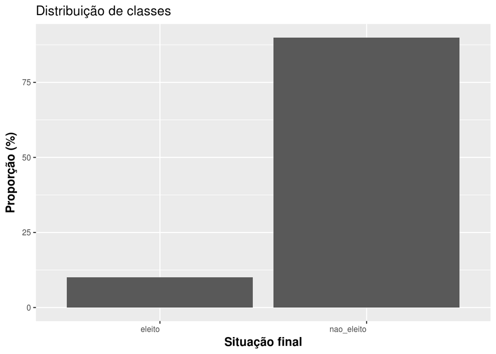

```r
total = nrow(dados)
dist_classes <- dados %>% count(situacao_final)

ggplot(dist_classes, aes(y = dist_classes$n/total * 100, x = dist_classes$situacao_final))+
  geom_bar(stat="identity") +
  labs(title = "Distribuição de classes", x = "Situação final", y = "Proporção (%)") +
  theme(axis.text.x = element_text(angle = 0, hjust = 1), legend.position="none") +
  theme(axis.text=element_text(size=8), axis.title=element_text(size=12,face="bold"))
```

Existem muito mais instâncias da classe “não eleito”, tornando os dados enviesados. Isso pode fazer com que o classificador fique tendencioso para classificar novas instâncias como sendo dessa classe, fazendo com que ele classifique erroneamente.

É possível balancear os dados usando o pacote ROSE.

```r
dados <- ROSE(situacao_final ~ UF + partido +   quantidade_doacoes +    quantidade_doadores +   total_receita   +   recursos_de_outros_candidatos.comites + recursos_de_partidos + recursos_de_pessoas_físicas +    recursos_de_pessoas_juridicas + recursos_proprios + quantidade_despesas +   quantidade_fornecedores +   total_despesa + sexo +  grau + estado_civil + descricao_ocupacao + descricao_cor_raca + despesa_max_campanha, data = dados, seed = 1)$data

prop.table(table(dados$situacao_final))
```

```
##
## nao_eleito     eleito
##  0.5180169  0.4819831
```

### 2. Treine: um modelo de regressão logística, uma árvore de decisão e um modelo de adaboost. Tune esses modelos usando validação cruzada e controle overfitting se necessário, considerando as particularidades de cada modelo.

Antes de criar os modelos é necessário separar os dados em duas partições, uma para treino e outra para validação.

```r
dataPartition <- createDataPartition(y = dados$situacao_final, p=0.75, list=FALSE)

treino <- dados[ dataPartition, ]
validacao <- dados[ -dataPartition, ]
```

# Regressão logística

```r
regLog <- train(formula,
                 data = treino,
                 method="glm",
                 family="binomial",
                 na.action = na.omit)
regLog
```

```
## Generalized Linear Model
##
## 3102 samples
##   19 predictors
##    2 classes: 'nao_eleito', 'eleito'
##
## No pre-processing
## Resampling: Bootstrapped (25 reps)
## Summary of sample sizes: 3102, 3102, 3102, 3102, 3102, 3102, ...
## Resampling results:
##
##   Accuracy   Kappa
##   0.9015782  0.8027158
```

# Árvore de decisão

```r
arvore <- train(formula,
                 data=treino,
                 method = "rpart",
                 cp=0.0005,
                 maxdepth=30)

arvore
```

```
## CART
##
## 3102 samples
##   19 predictors
##    2 classes: 'nao_eleito', 'eleito'
##
## No pre-processing
## Resampling: Bootstrapped (25 reps)
## Summary of sample sizes: 3102, 3102, 3102, 3102, 3102, 3102, ...
## Resampling results across tuning parameters:
##
##   cp          Accuracy   Kappa
##   0.06421405  0.9103649  0.8200073
##   0.12040134  0.8665098  0.7306181
##   0.68896321  0.7504675  0.4897397
##
## Accuracy was used to select the optimal model using the largest value.
## The final value used for the model was cp = 0.06421405.
```

# Adaboost

```r
#modelo <- train(formula,
#                data=treino,
#                method = "adaboost")

#modelo
```

### 3. Reporte acurácia, precision, recall e f-measure no treino e validação. Como você avalia os resultados? Justifique sua resposta.

```r
validacao$predicaoArv <- predict(arvore, validacao)

TP <- validacao %>% filter(situacao_final == "eleito", predicaoArv == "eleito") %>% nrow()
TN <- validacao %>% filter(situacao_final == "nao_eleito" , predicaoArv == "nao_eleito" ) %>% nrow()
FP <- validacao %>% filter(situacao_final == "nao_eleito" , predicaoArv == "eleito") %>% nrow()
FN <- validacao %>% filter(situacao_final == "eleito", predicaoArv == "nao_eleito" ) %>% nrow()

accuracy <- (TP + TN)/(TP + TN + FP + FN)
precision <- TP / (TP + FP)
recall <- TP / (TP + FN)

accuracy
```

```
## [1] 0.9012585
```

```r
precision
```

```
## [1] 0.9177215
```

```r
recall
```

```
## [1] 0.873494
```

Para o modelo de árvore de decisão temos uma acurácia de 0.9013, precisão de 0.9178 e recall de 0.8735.

```r
validacao$predicaoReg <- predict(regLog, validacao)
TP <- validacao %>% filter(situacao_final == "eleito", predicaoReg == "eleito") %>% nrow()
TN <- validacao %>% filter(situacao_final == "nao_eleito" , predicaoReg == "nao_eleito" ) %>% nrow()
FP <- validacao %>% filter(situacao_final == "nao_eleito" , predicaoReg == "eleito") %>% nrow()
FN <- validacao %>% filter(situacao_final == "eleito", predicaoReg == "nao_eleito" ) %>% nrow()

accuracy <- (TP + TN)/(TP + TN + FP + FN)
precision <- TP / (TP + FP)
recall <- TP / (TP + FN)

accuracy
```

```
## [1] 0.9177154
```

```r
precision
```

```
## [1] 0.9089109
```

```r
recall
```

```
## [1] 0.9216867
```

Para o modelo de regressão logística temos acurácia = 0.9177, precisão = 0.9089 e recall = 0.9217. Nesse contexto o mais importante é a precisão, pois o que mais interessa é saber se os cadidatos que o modelo afirma que são eleitos realmente são eleitos. Os resultados indicam que o modelo está muito bom.

### 4. Interprete as saídas dos modelos. Quais atributos parecem ser mais importantes de acordo com cada modelo? Crie pelo menos um novo atributo que não está nos dados originais e estude o impacto desse atributo

```r
varImp(arvore)
```

```
## rpart variable importance
##
##   only 20 most important variables shown (out of 239)
##
##                                                            Overall
## total_despesa                                               100.00
## recursos_de_partidos                                         94.19
## recursos_de_pessoas_juridicas                                89.56
## quantidade_despesas                                          87.05
## total_receita                                                80.66
## quantidade_doacoes                                           22.81
## `descricao_ocupacaoATOR E DIRETOR DE ESPETÁCULOS PÚBLICOS`    0.00
## partidoPMN                                                    0.00
## partidoPHS                                                    0.00
## descricao_ocupacaoCOZINHEIRO                                  0.00
## recursos_de_pessoas_físicas                                   0.00
## descricao_ocupacaoARQUITETO                                   0.00
## descricao_ocupacaoARTESÃO                                     0.00
## `estado_civilSOLTEIRO(A)`                                     0.00
## descricao_ocupacaoCOMERCIÁRIO                                 0.00
## `descricao_ocupacaoARTISTA PLÁSTICO E ASSEMELHADOS`           0.00
## partidoPROS                                                   0.00
## partidoPRP                                                    0.00
## descricao_ocupacaoPESCADOR                                    0.00
## `descricao_ocupacaoPOLICIAL MILITAR`                          0.00
```

É possível notar que as variáveis total_despesa, recursos_de_partidos, recursos_de pessoas_juridicas, quantidade_despesas e total_receita possuem uma importancia muito alta seguidas da variável quantidade_doacoes que também possui importancia, porém todas as demais variáveis não apresentam muita importncia ao usar árvore de decisão.

```r
varImp(regLog)
```

```
## glm variable importance
##
##   only 20 most important variables shown (out of 200)
##
##                                                                              Overall
## descricao_ocupacaoDEPUTADO                                                    100.00
## total_despesa                                                                  80.87
## quantidade_doacoes                                                             75.37
## descricao_ocupacaoAGRICULTOR                                                   65.65
## `descricao_ocupacaoCORRETOR DE IMÓVEIS, SEGUROS, TÍTULOS E VALORES`            58.48
## recursos_de_pessoas_físicas                                                    57.82
## total_receita                                                                  57.69
## recursos_de_pessoas_juridicas                                                  53.33
## descricao_ocupacaoINDUSTRIAL                                                   52.02
## `descricao_ocupacaoPOLICIAL CIVIL`                                             51.56
## recursos_de_outros_candidatos.comites                                          50.96
## sexoMASCULINO                                                                  49.91
## `estado_civilVIÚVO(A)`                                                         49.54
## `estado_civilDIVORCIADO(A)`                                                    49.06
## UFAM                                                                           47.59
## `descricao_ocupacaoLOCUTOR E COMENTARISTA DE RÁDIO E TELEVISÃO E RADIALISTA`   47.03
## descricao_ocupacaoADVOGADO                                                     46.53
## `descricao_ocupacaoJORNALISTA E REDATOR`                                       46.45
## descricao_ocupacaoPEDAGOGO                                                     44.94
## quantidade_despesas                                                            43.19
```

Ao utilizar regressão logística a importância das variáveis muda bastante, a mais importante deixa de ser total_despesa e passa a ser descricao_ocupacaoDEPUTADO, e as variáveis que não possuiam importância no modelo de árvore de decisão passa a ter uma importância considerável nesse modelo.

### 5. Envie seus melhores modelos à competição do Kaggle.

```r
submission_predict <- predict(arvore, teste)

for(i in 1:length(submission_predict)){
  print(submission_predict[i])
  submission$prediction[i] = submission_predict[i]
}
```

[output not shown]

[output cut: 1969 more lines]

[output not shown]

```r
write.csv(submission, file = "RenatoEly_submission.csv", row.names = FALSE)
```